# AnimalTA: A highly flexible and easy‐to‐use program for tracking and analysing animal movement in different environments - Chiara - 2023 - Methods in Ecology and Evolution - Wiley Online Library

[Yale University](https://library.yale.edu/)

[Methods in Ecology and Evolution](https://besjournals.onlinelibrary.wiley.com/journal/2041210x)

[Volume 14, Issue 7](https://besjournals.onlinelibrary.wiley.com/toc/2041210x/2023/14/7) p. 1699-1707

APPLICATION

Open Access

# AnimalTA: A highly flexible and easy-to-use program for tracking and analysing animal movement in different environments

[Violette Chiara](https://besjournals.onlinelibrary.wiley.com/authored-by/Chiara/Violette),

[Sin-Yeon Kim](https://besjournals.onlinelibrary.wiley.com/authored-by/Kim/Sin%E2%80%90Yeon),

First published: 15 May 2023

https://doi.org/10.1111/2041-210X.14115

**Handling Editor:** Giovanni Strona

## Abstract

1. Computer programs for video tracking of animal movement are evolving increasingly efficient, using complex algorithms or artificial intelligence systems. Despite the consequent progress in this field, researchers still face some fundamental problems in the use of such programs. For example, the best-performing programs are often uneasy to use, and user-friendly programs require source videos recorded under strict conditions (e.g. homogenous environments, constant lighting and high resolution), which may be difficult to meet in both laboratory and field studies.
2. We present here AnimalTA, a new program that tracks and analyses animal movement in diverse environments. This program aims to be accessible to everyone, including those without knowledge of coding and image analysis. AnimalTA allows to process rapidly a high number of videos and manage multi-arena tracking. It is adapted to follow the movement of targets in variable conditions, including heterogenous and complex environments, or in low-quality videos. AnimalTA provides tools for editing videos and correcting problems caused by camera tremors, light changes or perspective deformation.
3. AnimalTA also allows the user to easily correct tracking errors and repeat the tracking in a subsample of the video. The target's identity can be personalized to facilitate video analysis.
4. The tracking results can be analysed in AnimalTA to obtain many different variables related to the trajectory of each target, such as average speed, total distance travelled, latency to reach defined areas, distance to a defined point, distance to other individuals, number of contacts with others, explored surface, among others. Users can set and control different parameters for these analyses and directly view the results.

## 1 INTRODUCTION

Tracking the movement of animals is one of the most important methods used by scientists to study animal behaviour. Before the arrival of modern technologies, researchers measured the locomotion of animals simply by observing and describing it in the most objective way possible (Kline, 1899). The use of cameras and computers brought new tools to researchers, allowing an easier, faster and more objective way of measuring animal behaviour. A growing number of video tracking programs allow automated analyses of animal movement and behaviour (Dell et al., 2014), and the power and precision of these tools are rapidly improving. These modern programs use state-of-the-art technology, such as artificial intelligence, to follow the movement of up to a hundred identifiable individuals in the same arena (Ray & Stopfer, 2022; Romero-Ferrero et al., 2019; Walter & Couzin, 2021). These programs have their pros and cons, and despite a growing number of users, some practical difficulties in video tracking and analyses remain unsolved.

Some important limitations in most existing video tracking programs discourage their use in animal research. The first of those is accessibility: a good portion of these programs do not come with a simple installer. Instead, the user is commonly requested to have pre-installed additional software, such as MatLab, R or a Python environment (Harmer & Thomas, 2019; Panadeiro et al., 2021; Sridhar et al., 2019). Occasionally, the user is also required to write codes or modify existing ones (Mathis et al., 2018; Sridhar et al., 2019). In a recent paper, Panadeiro et al. (2021) reviewed 28 different video tracking programs, among which only four were user-friendly (Panadeiro et al., 2021). Many users often get frustrated when they are asked to install more supplementary programs or need to continuously look for information in the user-unfriendly user guidelines. Although these additional efforts might seem negligible to some people, it is often dissuasive for most users, as it implies a significant loss of time (personal observations).

The second most important problem of most video tracking programs is that the requirements of video quality and recording conditions are too demanding. For instance, some programs perform tracking over the whole video duration only (e.g. Pérez-Escudero et al., 2014; Walter & Couzin, 2021), so users need to crop their videos before the analysis using a video editing program. Most tracking programs also demand a specific video format, often different from the output of the user's video recording device (Panadeiro et al., 2021). For an efficient tracking, users also need to record videos under strictly controlled conditions. For example, to our knowledge, none of the existing programs is tolerant to camera tremors. Many programs stop tracking in the case of camera tremors, and some continue tracking but are unable to correct the target's trajectories biased by these tremors (e.g. Pérez-Escudero et al., 2014; Rodriguez et al., 2018; Romero-Ferrero et al., 2019; Walter & Couzin, 2021). Most tracking programs also demand videos of high resolution (in both spatial and temporal scales) with good lighting conditions and homogeneous background environments (see, e.g. the guidelines of ToxTrack and idTracker: Pérez-Escudero et al., 2014; Rodriguez et al., 2018). Meeting these requirements may pose a significant challenge, particularly in laboratories with limited budgets. Moreover, in many cases, it is not only difficult to meet such video-recording conditions, it is also necessary to use complex (and more realistic) environments for the sake of study design and natural animal behaviour.

Finally, many video tracking programs lack the ability to simultaneously analyse multiple arenas within a single video (Panadeiro et al., 2021). Because researchers need to replicate the same experiment multiple times, they often perform tests for several individuals simultaneously in multiple arenas. They also need to analyse several videos with the same experimental settings, but most tracking programs analyse videos one by one (Panadeiro et al., 2021).

Here, we introduce AnimalTA, a new video tracking software whose aim is not to bring new methods but to provide an easy-to-use tool that will allow researchers to rapidly analyse numerous videos with multiple arenas, recorded under more realistic conditions. For this end, AnimalTA provides built-in tools for light correction, image stabilization and perspective correction, and allows the user to fix multiple parameters related to target detection and target filtering. The program also allows the users to manually correct tracking errors, re-run the tracking with different parameters within a selected part of the video and easily obtain ready-to-use data adapted to their needs. To demonstrate the efficiency of AnimalTA, we compared the performances of AnimalTA and two other user-friendly programs in tracking and analysing the movement of various animals in multiple videos recorded under different conditions.

## 2 PRESENTATION OF ANIMALTA

### 2.1 Installation

The AnimalTA installer can be downloaded at: http://vchiara.eu/index.php/animalta, and the source code is accessible at: https://github.com/VioletteChiara/AnimalTA (Chiara, 2023). This program has been developed in Python for Windows OS and uses various Python libraries, mainly *Tkinter* as a Graphical User Interface (GUI), *OpenCv2* for image treatment and *decord* for video importation and reading.

AnimalTA can be downloaded with an installer in .exe file (built using Inno Setup: https://jrsoftware.org/isinfo.php). The guidelines can be downloaded at: http://vchiara.eu/index.php/animalta, but reading them is not mandatory to learn how to use AnimalTA. A comprehensible information panel is always visible on the top right corner of the application to guide and advise the user about what actions can/must be made. AnimalTA is available in five different languages (English, Chinese, Spanish, French and Galician).

### 2.2 Video loading

The user can work with multiple videos at the same time, although the maximum number of videos will depend on the characteristics of the computer and the resolution of the videos. AnimalTA will accept all possible video sizes and resolutions if the targets occupy less than one-third of the image. We advise that each target occupies more than 15 pixels. We recommend that users perform a pilot test before their experiments and test whether AnimalTA performs well for their videos. We were able to complete projects with up to a thousand 3-min videos (resolution: 1280 × 720) without any problem using AnimalTA with an ordinary laptop. The program uses .*avi* files for video analysis but allows the importation of various video formats, which will be convert to .*avi* before adding them to the project (tested with *avi*, *flv*, *mkv*, *mpeg*, *mpg*, *mp4*, *mts*, *m2v*, *m4v* and *wmv*). The imported raw video files can be modified and prepared in the program. For example, videos can be merged and cropped, a scale can be defined and the frame rate can be changed. It is also possible to apply a stabilization filter to correct unstable recording.

### 2.3 Video preparation

To identify the targets in the video, AnimalTA uses two different approaches. By default, targets are found using an adaptive thresholding method by which objects darker than their local environment are identified. This method is not frequently used in the existing tracking programs (but see Sridhar et al., 2019), but it allows for producing better tracking results than the frequently used background subtraction method, especially when the background is changing. The user can also choose to use the background subtraction method (Panadeiro et al., 2021; Sridhar et al., 2019), which automatically creates the background (an image of the video without the targets). The background is created by calculating the median value of each pixel in a subsample of images from the grayscale video. The background subtraction method can fail if the target remains in the same place for more than half the duration of the video. However, the user can visualize the produced background and manually correct its errors before starting the tracking process. The user can freely choose a preferred option between the adaptive thresholding method and the background subtraction method.

### 2.4 Tracking parameters

Once the videos are prepared, the user can proceed with the tracking in the next panel. In this new panel, the user can set various parameters to optimize the quality of the tracking. For example, set the threshold values of target detection (e.g. by size), specify the number of targets for each arena, limit the threshold distance a target can move between two frames, activate lighting or flickering correction and add erosion and dilation filters to the binary image. During this process, the effects of the parameter settings are immediately visualized in a video panel. The flexible parameter settings ensure efficient and accurate tracking even for low-quality videos with changing luminosity or other imperfections.

### 2.5 Tracking process

If several targets are identified within a frame, identities will be assigned in a way to minimize the distance between the last seen position and the current one of all targets (Trucco & Plakas, 2006). When several targets are in contact, identification errors may be produced. To reduce these errors, we used the *KMeans* function from the *scipy* library to find the centre of these targets (Sridhar et al., 2019). The same tracking can be performed on multiple videos with a single operation by applying the same video preparation, tracking and analysis processes in several videos. If the videos were recorded under similar conditions and the user wishes to analyse them in the same manner, the user needs to define the parameters only once. After applying the same parameters to all videos, it is always possible to modify the parameters of a single video without altering the parameters of the other videos.

### 2.6 Correction of the tracked trajectories

After tracking, the user can manually correct the tracking results, if necessary, via four different methods: (i) changing the coordinates of a target in a specific frame by simply dragging and dropping it, (ii) removing the previous coordinates and click on the target positions, (iii) using the ‘interpolation’ option to select two frames between which the coordinates of the target will be interpolated and (iv) using the ‘redo tracking’ option to select a part of the video and redo the tracking process with modified parameters. A Savitzky–Golay smoothing filter (Press & Teukolsky, 1990) can also be applied to reduce the noise associated with tracking imprecisions. This digital filter applies a convolution of the data: It filters successive subsets of data with low-degree polynomial by the linear least squares method. In this way, the movement trajectories are smoothed, and their accuracy is improved without being distorted.

### 2.7 Analyses of the tracked trajectories

AnimalTA provides numerous functions to analyse the trajectories of individual movement obtained by AnimalTA video tracking. Movement trajectories of a single target, such as the total distance moved, the average speed, the meander value, among others, can be analysed by following brief and straightforward instructions shown in the information panel. For these analyses, the user can set or select several parameters, such as the distance threshold that a target is considered moving, the method used to calculate the proportion of explored area, the shape and cell size of the grids used to measure exploration (if this solution is chosen by the user) and the size of the area around the target that is considered as explored while the target is moving. The program instantly shows how the changes in different parameter settings will affect the results. It is also possible to set elements of interest, such as the time each target spent in an area set by the user, the time spent in the border of the arena, and the mean distance to a point, among others. Some examples of analyses are illustrated and described in Figure 1.

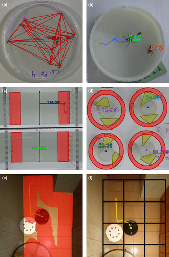

**FIGURE 1**

Brief overview of some analysis features produced by AnimalTA with different kinds of targets (a & d: Ants, b: Spiders, c: Fish, e–f: Vacuum robot). (a) Inter-individual distances: when several targets are inside the same arena, AnimalTA measures inter-individual distances and calculates their sum (shown on the image produced by AnimalTA), the average distance between each pair of targets, the proportion of time each pair of targets spent together, the number of contact events between those targets, the proportion of time a target spent with at least one other target in the vicinity, etc. (b) The state of each target is recorded as moving or stopped (above or below the threshold of movement speed defined by the user). The user can directly see on the video the speed of displacement of each target and whether it is considered as moving (text with green contour) or stopped (text with red contour). AnimalTA then calculates for each target the proportion of time spent moving, the average speed, the total distance travelled, etc. (c and d). The user can add different elements of interest inside the arena, such as areas, segments and points. For example, two rectangular arenas and one segment are set in each arena of (c), and a border area and two polygons are set in (d) arenas. According to the type of element, different measurements can be obtained (for areas: latency to enter, the proportion of time inside; for segments: average distance to the segment, number of times the targets cross it; for points: average distance to the point, latency to approach it, proportion of time spent close to it; for borders: proportion of time at the border, latency to reach it). (e and f) Two different methods to measure the exploration. (e) presents a method that defines an exploration area (a circular area around a target at each moment) and calculates the proportion of the arena explored by the moving target (Ruhland et al., 2016). (f) is a typical method of exploration measurement for which the arena is divided into cells of equal size. The area of exploration around the target in (e) and the size of each individual cell in (f) are defined by the user.

When more than one target is present inside an arena, the user also obtains information about inter-individual interactions, such as the duration of all between-target interactions, the proportion of time two targets spent close to each other and multiple other measures. AnimalTA also allows the user to rename the targets after the tracking process. Thus, the user can easily identify the individuals and interpret the results while looking at the tracking video (see Figure 2f).

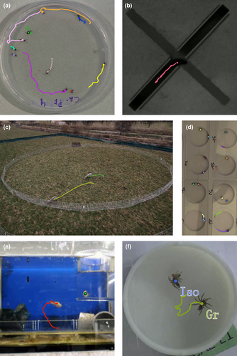

**FIGURE 2**

Illustrations of the tracking results obtained by AnimalTA (without manual correction or image modification) in various situations. These images were extracted from the video output of AnimalTA. (a) A group of ants: one arena, multiple individuals, homogeneous background, high-resolution video. (b) Mouse in an elevated plus maze: one arena with one individual, low resolution, low luminosity. (c) A pair of sheep moving inside a fence: very high-resolution video (4 K), low frame rate (1fps), camera tremors, severe changes in luminosity, heterogeneous background. (d) Spiders in aggressiveness test: multiple arenas, two individuals per arena, high-resolution video. (e) Fish courtship behaviour: two targets, heterogeneous background, changes in target size and luminosity. (f) Spider predation behaviour: one arena, two individuals, non-uniform lighting, presence of a perturbation element (prey).

The strengths of AnimalTA are its ultimate user-friendly nature, its flexibility with experimental design and video quality, the ability of analysing numerous videos simultaneously, the integration of various tools of tracking and both basic and complex analyses and the ability to correct potential tracking errors.

However, AnimalTA also has some limitations. AnimalTA may confuse the identity of different targets within the same arena if they cross and their central positions overlap. This problem may occur especially when animals distribute in a three-dimensional (3D) environment, for example, fish swimming over each other in water (see Supplementary Video: E). In two-dimensional (2D) environments in which individuals do not cross over each other, the target identities will be preserved even if they make contacts (see Supplementary Videos: M, O). Therefore, we advise users who need to track individual trajectories in grouped animals, especially swimming or flying animals, to choose other programs with strong competence in distinguishing between different individuals, such as idTracker (Pérez-Escudero et al., 2014), idTracker.ai (Romero-Ferrero et al., 2019) and ToxTrack (Rodriguez et al., 2018). Another limitation of AnimalTA is its portability, as it is currently only available for the Windows operating system. AnimalTA does not include artificial intelligence (AI) or complex algorithms. Thus, it cannot recognize and distinguish different postures of the target or track a specific part of its body, such as the head or legs. Moreover, contrary to some AI-based programs (Feng & Xiao, 2022; Ray & Stopfer, 2022), AnimalTA does not work properly for videos recorded in changing or moving environments.

### 2.8 AnimalTA tracking results and the comparison with other programs

We tested AnimalTA by using 19 videos with different kinds of targets (slime-mould cells, ants, spiders, crickets, snails, fish, mice, sheep, primates and a vacuum robot; Videos S1–S19), with both single and multiple arenas and with both single and multiple individuals per arena (Figure 2, Table 1, Videos S1–S19, Table S1). For comparison purposes, we also tracked and analysed the same videos with two other video tracking programs: ToxTrack (Rodriguez et al., 2018) and TRex (Walter & Couzin, 2021). We chose these two programs for comparison because they both present similar objectives and features to AnimalTA with an emphasis on being user-friendly and performing fast analyses. ToxTrack also provides multi-arena and multi-individual tracking functions although it requires videos with homogeneous backgrounds and good recording quality. TRex is not specialized in multi-arena tracking but allows tracking of numerous individuals.

TABLE 1. Summary of the tracking performances of AnimalTA, ToxTrack and TRex in videos with different qualities, animal species and experimental settings. The 19 videos are ordered from A (good recording conditions) to S (bad recording conditions). More information about the characteristics and study purpose of the videos are available in Supporting Information (Table S1). The time taken by each program to process the video and the proportion of frames in which the targets were identified (detection rate) are summarized. The comparison of the results with ground truth data is also summarized (distance between the automatically and manually tracked positions). The number of times that target identities needed to be swapped to correct the tracking data of up to four targets for the comparison with ground truth data is also shown in the ‘Identity swaps’ columns. Although AnimalTA allows to manually correct tracking mistakes, all the data presented here are uncorrected to ensure a fair comparison among different programs. All these videos can be found in the Supporting Information (Videos S1–S19), along with information about parameter values set in AnimalTA to obtain the presented results (Table S2). *The detection of the targets failed due to heterogenous background. **The number of identity swaps was too high to ensure a correct correction of the tracking.

|  | AnimalTA |  |  |  | ToxTrack |  |  |  |  | TRex |  |  |  |  | Ref |
| --- | --- | --- | --- | --- | --- | --- | --- | --- | --- | --- | --- | --- | --- | --- | --- |
| Video | Time taken (s) | Detection rate (%) | Distance to ground truth (mean ± SD) | Identity swaps | Time taken (s) | Detection rate (%) | Distance to ground truth (mean ± SD) | Identity swaps | Untracked individuals | Time taken (s) | Detection rate (%) | Distance to ground truth (mean ± SD) | Identity swaps | Untracked individuals |  |
| A Fish sociability | 11 | 99.97 | 3.1 ± 1.9 | 0 | 10 | 100 | 4.4 ± 2.0 | 0 | 0/2 | 4 | 99.60 | 4.6 ± 2.0 | 0 | 0/2 | NA |
| B Damselfly locomotion | 30 | 99.99 | 4.5 ± 2.3 | 0 | 9 | 91.27 | 4.4 ± 3.4 | 0 | 2/12 | 3 | 100 | 8.34 ± 2.1 | 0 | 2/12 | Sanmartín-Villar et al. (2022) |
| C Fish boldness | 1 | 51.97 | 2.6 ± 1.6 | NA | 2 | 51.17 | 2.6 ± 1.6 | NA | 0/1 | 1 | 51.17 | 5.2 ± 1.9 | NA | 0/1 | NA |
| D Spider aggression | 40 | 99.99 | 3.0 ± 2.2 | 4 | 10 | 55.20 | 1.7 ± 1.0 | 5 | 8/36 | 4 | ** |  |  |  | Chiara et al. (2019) |
| E Fish shoaling | 12 | 100 | 8.7 ± 15.5 | 17 | 3 | 63.10 | 3.4 ± 8.6 | 17 | 0/4 | 3 | 77.75 | 16.2 ± 47.9 | 12 | 0/4 | NA |
| F Mouse locomotion | 1 | 100 | 6.0 ± 3.9 | NA | 2 | 99.86 | 7.9 ± 3.6 | NA | 0/1 | 2 | 90.70 | 11.7 ± 3.2 | NA | 0/1 | NA |
| G Spider locomotion | 10 | 100 | 4.2 ± 2.2 | NA | 11 | 99.20 | 5.8 ± 3.1 | NA | 0/1 | 4 | 91.08 | 29.2 ± 7.5 | NA | 0/1 | Inspired from Ruhland et al. (2016) |
| H Spider predation | 3 | 100 | 4.3 ± 2.9 | 0 | 5 | 56.10 | 7.2 ± 2.9 | 0 | 0/2 | 2 | 67.90 | 6.8 ± 3.3 | 0 | 0/2 | Chiara and Jeanson (2020) |
| I Vacuum robot | 18 | 96.40 | 17.6 ± 9.6 | NA | 54 | 55.44 | 14.7 ± 11.0 | NA | 0/1 | 6 | 83.94 | 17.6 ± 11.3 | NA | 0/1 | NA |
| J Cricket locomotion | 1 | 100 | 1.1 ± 0.6 | 0 | 1 | 82.87 | 1.8 ± 1.0 | 0 | 0/2 | 1 | 100 | 1.5 ± 0.9 | 0 | 0/2 | Noguera (2021) |
| K Mouse EPM | 1 | 100 | 9.1 ± 6.7 | NA | 2 | 17.00 | 12.6 ± 2.2 | NA | 0/1 | 2 | 48.72 | 11.3 ± 6.4 | NA | 0/1 | NA |
| L Ant foraging 1 | 5 | 97.51 | 2.7 ± 1.0 | 0 | 3 | 57.94 | 6.6 ± 15.7 | 0 | 2/9 | 3 | 66.89 | 28.5 ± 80.9 | 3 | 3/9 | NA |
| M Ant sociability | 11 | 99.93 | 2.5 ± 1.7 | 0 | 23 | 89.45 | 2.3 ± 1.4 | 7 | 0/10 | 4 | ** |  |  |  | NA |
| N Phagocytosis | 4 | 100 | 5.4 ± 2.9 | 0 | 100 | 100.00 | 12.7 ± NA | 0 | 2/3 | 3 | 55.38 | 5.5 ± 3.5 | 0 | 0/3 | NA |
| O Fish courtship | 2 | 99.9 | 3.4 ± 2.0 | 0 | * |  |  |  |  | 2 | 99.58 | 2.6 ± 1.9 | 0 | 0/2 | Chiara et al. (2022) |
| P Snail locomotion | 18 | 98.94 | 14.2 ± 5.0 | 0 |  |  |  |  |  | 22 | 87.61 | 92.7 ± 216 | 2 | 0/2 | NA |
| Q Sheep sociability | 24 | 100 | 38.5 ± 12.7 | 0 |  |  |  |  |  | 8 | 95.08 | 1500 ± 1356.3 | 1 | 0/2 | NA |
| R Ant foraging 2 | 1 | 100 | 4.9 ± 2.1 | NA |  |  |  |  |  | 1 | 90.38 | 4.71 ± 2.1 | NA | 0/1 | Ślipiński and Cerdá (2022) |
| S Marmoset | 67 | 100 | 48.9 ± 39.4 | 0 |  |  |  |  |  | 23 | 19.98 | 259.8 ± 179.8 | 1 | 0/2 | NA |

## 3 CONCLUSION

In this article, we introduce AnimalTA, an easy-to-use and highly flexible video tracking program to study animal behaviour and movement. AnimalTA has both strengths and limitations in comparison to other already existing tracking programs. The most prominent strengths of AnimalTA are its accessibility, its flexibility with source videos and its ability to analyse the tracked trajectories within the same program. The major limitation of AnimalTA is its poor capacity to maintain target identity in 3D environments and track targets moving in a changing environment. This new program will be especially useful for researchers who cannot always test animal behaviour in perfect conditions with homogeneous backgrounds due to the nature of study species, experimental design or limited budget.

## AUTHOR CONTRIBUTIONS

Violette Chiara coded the program. Violette Chiara and Sin-Yeon Kim led the writing of the manuscript. Sin-Yeon Kim tested the program and supervised the work. Both authors contributed critically to the drafts and gave final approval for publication.

## ACKNOWLEDGEMENTS

We are grateful to Iago Sanmartín Villar, Srikrishna Narasimhan, Mireille Chiara-Thedy, Jean-Yves Chiara and Qunli Yao for their help in translating program information and testing AnimalTA. We also thank José Noguera and Alberto Velando for helpful discussion and two anonymous reviewers for constructive comments to both our program and manuscript. We thank Richard Bon, Enikö Csatka, Josselin Duffrene, Audrey Dussutour, Pascal Girard, Adrien Lamaze, José Noguera, Benjamin Portal, Gema Trigos Peral, Iago Sanmartín Villar and Piotr Ślipiński for sharing their videos. This work was supported by research grants provided by the Ministerio de Ciencia, Innovación y Universidades (RYC-2015-18317; PGC2018-095412-B386 I00). V.C. was funded by the Fyssen Foundation grant.

## CONFLICT OF INTEREST STATEMENT

All authors declare that they have no conflicts of interest.

## REFERENCES

back